#### Ryan Dotzlaw

##### Write functions *deleted_row_sum* and *deleted_col_sum*

Both functions will take a square matrix *M* of dim = n as a parameter and each will return a vector of all the row/col sums.

Each row/col sum is the sum of the absolute values in the all the entries in the ith row/col excluding the ‘deleted’ ith entry.

```r
deleted_row_sum = function(M){
  # ensure M is square
  if(dim(M)[1] != dim(M)[2]){
    # return error, quit function
    stop("Matrix given is not square.")
  }
  # continue
  # result is empty vector of size 'n x 1'
  res = matrix(nr=dim(M)[1], nc=1)
  for(i in 1:dim(M)[1]){
    deleted_i = 0
    # sum up all the values in ith row, excluding the ith value
    # deleted_i = sum(abs(M[i])) - abs(M[i,i])
    for(j in 1:dim(M)[1]){
      if(j != i){
        deleted_i = deleted_i + abs(M[i,j])
      } # else to do nothing
      res[i] = deleted_i
    }
  }
  return(res)
}
```

```r
deleted_col_sum = function(M){
  # ensure M is square
  if(dim(M)[1] != dim(M)[2]){
    # return error, quit function
    stop("Matrix given is not square.")
  }
  # continue
  # result is empty vector of size 'n x 1'
  res = matrix(nr=dim(M)[1], nc=1)
  for(i in 1:dim(M)[1]){
    # sum up all the values in ith col, then cancel out ith value
    deleted_i = 0
    for(j in 1:dim(M)[1]){
      if(j != i){
        deleted_i = deleted_i + abs(M[j,i])
      } # else to do nothing
      res[i] = deleted_i
    }
    res[i] = deleted_i
  }
  return(res)
}
```

##### Write function *gershgorin_disks*

Takes a square matrix M

Returns a 2-tuple of dataframes

1 dataframe is row_disks, the other is col_disks, so return is c(row_disks, col_disks)

both dataframes contain a column called ‘center’ containing the center coordinates of the disk and another column called ‘radius’ containing the radius of each disk.

The center of each disk in row_disk or col_disk is the deleted ith value, specifically the values on the main diagonal.

The radius of each disk is the deleted_row/col_sum associated with each center.

```r
gershgorin_disks = function(M){
  # ensure M is square
  if(dim(M)[1] != dim(M)[2]){
    # return error, quit function
    stop("Matrix given is not square.")
  }
  # continue

  # declare return values
  row_disks = data.frame(matrix(nr=dim(M)[1],nc=2))
  col_disks = data.frame(matrix(nr=dim(M)[1],nc=2))
  colnames(row_disks) = c("center", "radius")
  colnames(col_disks) = c("center", "radius")


  # define return values
  row_disks$radius = deleted_row_sum(M)
  col_disks$radius = deleted_col_sum(M)

  row_disks$center = diag(M)
  col_disks$center = diag(M)
  return(list(row_disks, col_disks))
}
```

##### Write function *plot_gg_disks*

Takes square matrix ‘M’

Will plot both the ‘row_disks’ and the ‘col_disks’ from the *gershgorin_disks* function

Use distinct colors for the row disks and the col disks, so you know which is which

Will not be using fill when coloring the disks, due to the possibility of overlap, instead will just be doing an outline, which is technically not accurate, but I figured as long as I acknowledged it, the increase in clarity would be worth it.

```r
plot_gg_disks = function(M){
  # ensure M is square
  if(dim(M)[1] != dim(M)[2]){
    # return error, quit function
    stop("Matrix given is not square.")
  }
  # continue
  disks = gershgorin_disks(M)
  # print(disks)
  # plot row_disk

  # get data to plot
  r_x = Re(as.data.frame(disks[1])$center)
  r_y = Im(as.data.frame(disks[1])$center)
  r_r = Re(as.data.frame(disks[1])$radius)
  # * Since radius is the sum of absolute values, |i| = 1, so it's always Real
  # but, just to be sure
  c_x = Re(as.data.frame(disks[2])$center)
  c_y = Im(as.data.frame(disks[2])$center)
  c_r = Re(as.data.frame(disks[2])$radius)

  # construct dataframes to plot
  circ1 = data.frame(
    x = r_x,
    y = r_y,
    r = r_r
  )
  circ2 = data.frame(
    x = c_x,
    y = c_y,
    r = c_r
  )

  print("row disks are:")
  print(circ1)
  print("col disks are:")
  print(circ2)

  # plot both row and col disks
  ggplot() +
    geom_circle(aes(x0 = x, y0 = y, r = r), data=circ1, color="red") +
    geom_circle(aes(x0 = x, y0 = y, r = r), data=circ2, color="blue") +
    labs(x="Real Numbers", y="Imaginary Numbers") + coord_fixed()


}
```

##### Write functions *make_row_stochastic_matrix* and *make_col_stochastic_matrix*

Start by making a helper function to normalize vectors

```r
normalize = function(vec){
  return(vec / sqrt(sum(vec^2)))
}
```

A matrix is row stochastic if:

No entry is equal to zero

Non-Negative Matrix (all entries positive)

Create a square matrix of size ‘n’

```r
make_row_stochastic_matrix = function(n){
  # n x n matrix, all NA
  mat = matrix(nc=n,nr=n)
  # generate random n x 1 vectors, all normalized
  for(i in c(1:n)){
    mat[i,] = normalize(runif(n, 0, 2))
  }
  return(mat)
}
```

A matrix is col stochastic if:

No entry is equal to zero

Non-Negative Matrix (all entries positive)

Create a square matrix of size ‘n’

```r
make_col_stochastic_matrix = function(n){
  # n x n matrix, all NA
  mat = matrix(nc=n,nr=n)
  # generate random n x 1 vectors, all normalized
  for(i in c(1:n)){
    mat[,i] = normalize(runif(n, 0, 2))
  }
  return(mat)
}
```

##### Use *plot_gg_disks* to plot the disks associated with the matrices in Q1

```
## [1] "row disks are:"
##    x y r
## 1  1 0 1
## 2 -2 0 1
## [1] "col disks are:"
##    x y r
## 1  1 0 1
## 2 -2 0 1
```

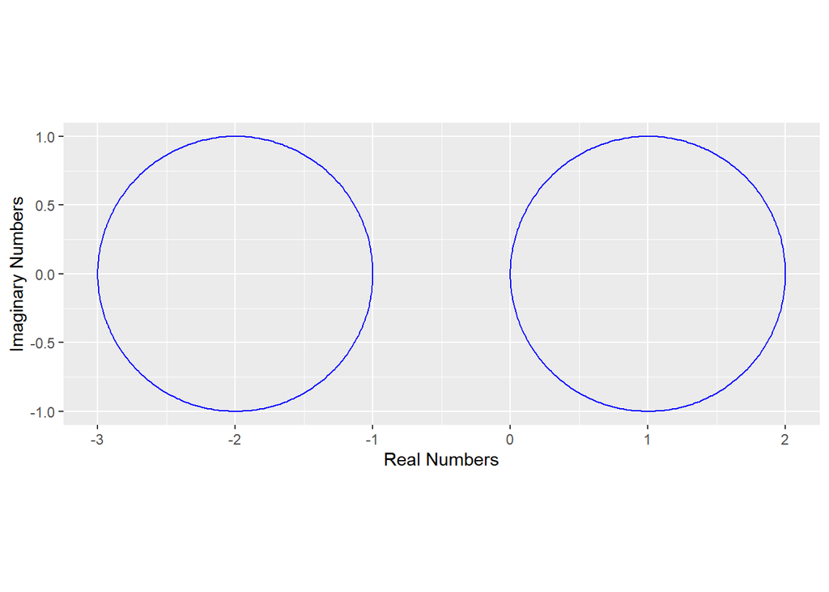

```r
# ggplot2 extension package that has geom_circle in it
if (!require("ggforce")) {
    install.packages("ggforce")
    library(ggforce)
}
A = matrix(c(1, -1, 1, -2), nc=2, nr=2)
B = matrix(c(2, -1, 1i, 1, 1+2i, 0, 1, 2, -1), nc=3, nr=3)
plot_gg_disks(A)
```

```
## [1] "row disks are:"
##    x y r
## 1  2 0 2
## 2  1 2 3
## 3 -1 0 1
## [1] "col disks are:"
##    x y r
## 1  2 0 2
## 2  1 2 1
## 3 -1 0 3
```

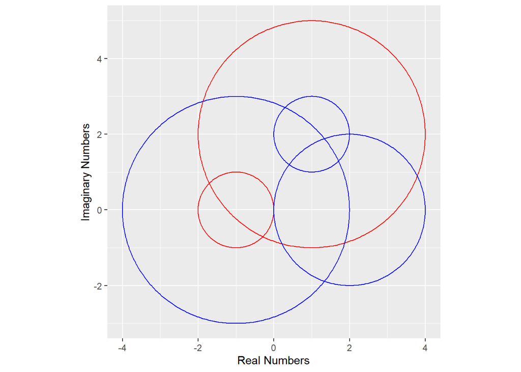

```r
plot_gg_disks(B)
```

##### Plot Random Stochastic Matrices

```r
S1 = make_row_stochastic_matrix(5)
S1
```

```
##           [,1]      [,2]      [,3]       [,4]      [,5]
## [1,] 0.5148093 0.5459863 0.3979048 0.50716414 0.1460365
## [2,] 0.4766335 0.8404548 0.1053752 0.06975258 0.2246930
## [3,] 0.1617591 0.0160156 0.0472864 0.67656080 0.7166638
## [4,] 0.5287457 0.5341048 0.1808659 0.33785498 0.5369372
## [5,] 0.2764034 0.4884809 0.5626943 0.59682373 0.1102913
```

```r
S2 = make_col_stochastic_matrix(5)
S2
```

```
##           [,1]       [,2]      [,3]      [,4]       [,5]
## [1,] 0.5581630 0.61107192 0.1159964 0.4579087 0.07239551
## [2,] 0.1555763 0.38608039 0.3032119 0.6188590 0.56072628
## [3,] 0.3065470 0.08878685 0.1543963 0.1277550 0.52300009
## [4,] 0.5513180 0.60798285 0.6080962 0.1969303 0.55387090
## [5,] 0.5160692 0.31623850 0.7078051 0.5934899 0.31629554
```

```
## [1] "row disks are:"
##           x y         r
## 1 0.5148093 0 1.5970917
## 2 0.8404548 0 0.8764543
## 3 0.0472864 0 1.5709993
## 4 0.3378550 0 1.7806536
## 5 0.1102913 0 1.9244023
## [1] "col disks are:"
##           x y        r
## 1 0.5148093 0 1.443542
## 2 0.8404548 0 1.584588
## 3 0.0472864 0 1.246840
## 4 0.3378550 0 1.850301
## 5 0.1102913 0 1.624330
```

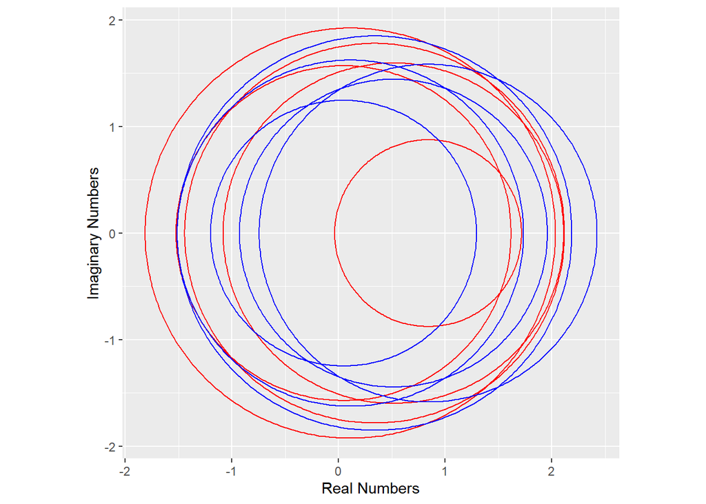

```r
plot_gg_disks(S1)
```

```
## [1] "row disks are:"
##           x y        r
## 1 0.5581630 0 1.257373
## 2 0.3860804 0 1.638373
## 3 0.1543963 0 1.046089
## 4 0.1969303 0 2.321268
## 5 0.3162955 0 2.133603
## [1] "col disks are:"
##           x y        r
## 1 0.5581630 0 1.529511
## 2 0.3860804 0 1.624080
## 3 0.1543963 0 1.735110
## 4 0.1969303 0 1.798013
## 5 0.3162955 0 1.709993
```

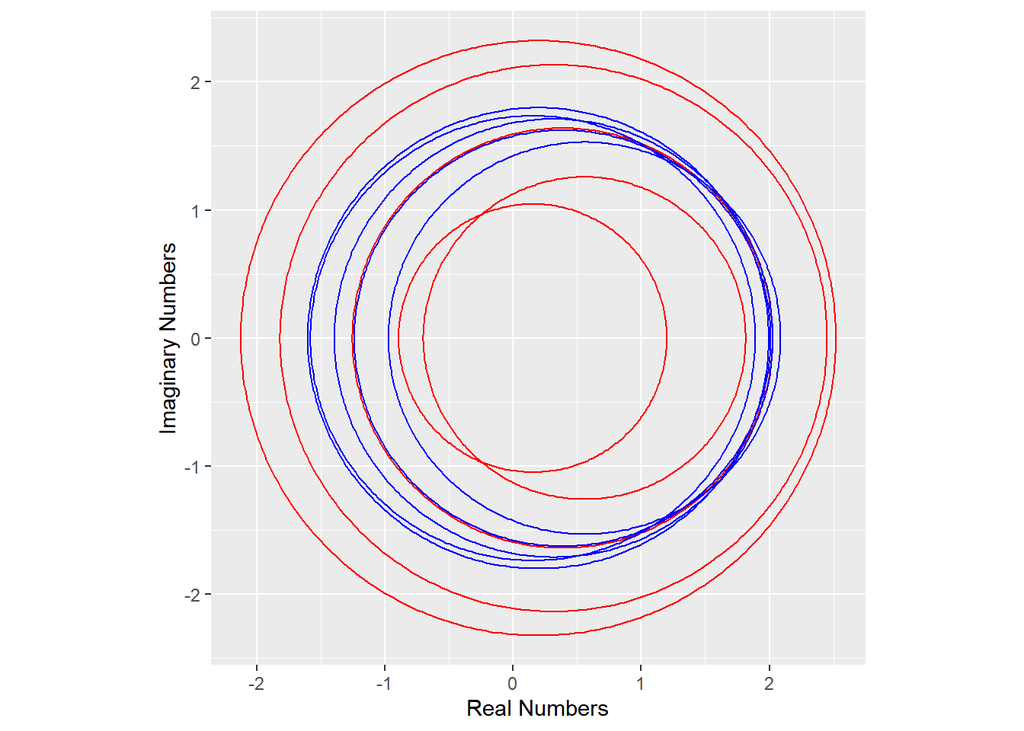

```r
plot_gg_disks(S2)
```